# Group project

Group Number 3

Sviatoslav Naumov

Fuad Mahamed

Fabio Pugno

2026-06-06

# Checklist

The submission includes the following.

- RMD document where it’s clear what is the code that corresponds to each question.
- Link to the dataset
- html/PDF document with the following
  - Numbered questions and answers with text and all the necessary code.
  - Subtitle indicates the group number
  - Name of all group members
  - Details of specification of the work done by group members (e.g., who found the data, who did the pre-processing, who answered which questions, etc).
  - Statement of technology (see template below): which AI tools you used, for which questions, and for what kind of help.

# Important — read before you start

- **Assignments that do not follow this template will not be graded.** Use the structure, the question numbering, and the order given here.
- **Each question has a maximum word count.** Code, plots, and tables don’t count toward the limit, but explanations, justifications, and conclusions do. Anything beyond the limit will not be read. Be focused — do not pad your answers.
- **Answer only what is asked.** Do not add extra models, extra plots, extra metrics, or side analyses that the question does not request. Points will be deducted from any question that includes irrelevant content, even if that content is correct.

# Group project

For the project, we use the following packages:

```r
## ...
library(dplyr)
library(brms)
library(ggplot2)
library(tidyr)
library(bayesplot)
library(priorsense)
library(patchwork)
library(loo)
library(matrixStats)
```

## 1. Dataset Selection (0.5pt)

Slava Select a dataset with clusters such as schools, regions, or people with multiple observations per individual (e.g., from https://www.kaggle.com/). Choose a small dataset (e.g., fewer than 1000 rows) or subset it so that fitting the models doesn’t take too long.

1. Describe the dataset with a couple of short sentences. What was its intended use? Are there papers that reference it? Provide information on how to obtain the dataset, including its source and any necessary preprocessing steps/feature engineering. *(Max 200 words.)*

The data represents CO2 emissions of 100 largest global companies from 2022 to 2024. The major cluster variables are sectors, countries and companies.

The data can be found on Kaggle: https://www.kaggle.com/datasets/hussnainmamoon1/ghg-emissions-and-finance-global-companies-2022-2024?resource=download The data is already clean. Major data sources used by the contributors included companies’ annual reports, and financial data portals. To the best of authors knowledge, this particular dataset has not been referenced by any research.

```r
ghg_all <- read.csv("ghg_financial_global_2022_2024_clean.csv")
ghg_df <- select(ghg_all,c('company_name','country', 'sector', 'year', 'scope1_co2e_tonnes','revenue_usd_m','country_renewable_energy_pct'))
```

```r
ghg_df$country <- as.factor(ghg_df$country)
ghg_df$sector <- as.factor(ghg_df$sector)
ghg_df$co2_mt <- round(ghg_df$scope1_co2e_tonnes/1000000,2)
ghg_df$revenue_b <- round(ghg_df$revenue_usd_m/1000,2)
```

2. Report the number of observations, columns (with their meaning) and their data types. Indicate clearly what you will use as dependent variable/label. *(Max 150 words; a short table of columns is fine and does not count toward the limit.)*

There are 300 rows (observations).

The dependent variable is co2_mt: direct company’s CO2-equivalent greenhouse gas emissions (in million tonnes) per year. - co2_mt — Scope 1 CO2e emissions in million tonnes (dependent variable); numeric

We are trying to predict the co2 variable based on the following factors: - year — year of observation, 2022–2024; integer (treated as a factor in m3) - revenue_b — company revenue in billion USD; numeric - sector — economic sector; factor - country — country of headquarters; factor - country_renewable_energy_pct — % renewable energy in the country; numeric

```r
summary(ghg_df)
```

```
 company_name                 country                 sector         year
 Length:300         United States :165   Consumer Staples: 30   Min.   :2022
 Class :character   United Kingdom: 27   Energy          : 30   1st Qu.:2022
 Mode  :character   Germany       : 24   Financials      : 30   Median :2023
                    Switzerland   : 18   Healthcare      : 30   Mean   :2023
                    France        : 12   Industrials     : 30   3rd Qu.:2024
                    Brazil        :  6   Materials       : 30   Max.   :2024
                    (Other)       : 48   (Other)         :120
 scope1_co2e_tonnes  revenue_usd_m    country_renewable_energy_pct     co2_mt
 Min.   :     7872   Min.   :  5800   Min.   : 8.0                 Min.   :  0.010
 1st Qu.:   502950   1st Qu.: 33475   1st Qu.:22.0                 1st Qu.:  0.505
 Median :  5181000   Median : 57770   Median :22.0                 Median :  5.180
 Mean   : 19054646   Mean   : 86439   Mean   :32.7                 Mean   : 19.055
 3rd Qu.: 22155000   3rd Qu.: 99668   3rd Qu.:41.5                 3rd Qu.: 22.155
 Max.   :162750000   Max.   :434583   Max.   :98.0                 Max.   :162.750

   revenue_b
 Min.   :  5.80
 1st Qu.: 33.48
 Median : 57.77
 Mean   : 86.44
 3rd Qu.: 99.67
 Max.   :434.58
```

## 2. Model Exploration (3.5pt)

First split the data into training (80%) and test set (20%). Transform the columns if necessary.

```r
set.seed(123)
ghg_train <- slice_sample(ghg_df, prop = .8)
ghg_test  <- anti_join(ghg_df, ghg_train, by = colnames(ghg_df))
```

1. Fit multiple appropriate models to the dataset: **as many models as there are members in the group, with a minimum of two**. Models must differ in a substantive way — **at least one must be a multilevel model**; differences can be in the multilevel structure, in the likelihood/data model, or in the informativeness of the priors (trivial prior tweaks do not count as a different model). I recommend against no-pooling models, as they tend to take a long time and it is hard to assign good priors. **Assess whether each model converged: report what the traceplots look like, the highest Rhat, the number of effective samples, etc. If a model did not converge, address the issues. If you cannot solve the problems, report them and continue with the assignment.**
2. Explain each model and describe its structure (what it assumes about population-level and group-level effects) and the priors used. *(Max 150 words per model.)*

```r
# model 1 go here
m1 <- brm(co2_mt ~ country_renewable_energy_pct + revenue_b + (1|sector),
          data = ghg_train,family = gaussian(),seed = 123)

m2 <- brm(co2_mt ~ country_renewable_energy_pct + revenue_b +
    (1 | sector) + (1 | country),
  data = ghg_train,
  family = gaussian(),
  seed = 123,
  control = list(adapt_delta = 0.99)
)

ghg_train$year <- factor(ghg_train$year)

m3 <- brm(
  co2_mt ~ year + country_renewable_energy_pct + revenue_b +
    (1 | sector),
  data = ghg_train,
  family = gaussian(),
  seed = 123
)
```

```r
summary(m1)
```

```
 Family: gaussian
  Links: mu = identity
Formula: co2_mt ~ country_renewable_energy_pct + revenue_b + (1 | sector)
   Data: ghg_train (Number of observations: 240)
  Draws: 4 chains, each with iter = 2000; warmup = 1000; thin = 1;
         total post-warmup draws = 4000

Multilevel Hyperparameters:
~sector (Number of levels: 11)
              Estimate Est.Error l-95% CI u-95% CI Rhat Bulk_ESS Tail_ESS
sd(Intercept)    25.77      5.79    16.95    39.74 1.00      939     1554

Regression Coefficients:
                             Estimate Est.Error l-95% CI u-95% CI Rhat Bulk_ESS Tail_ESS
Intercept                       -2.47      7.33   -15.50    12.90 1.00      874     1317
country_renewable_energy_pct     0.21      0.08     0.05     0.37 1.00     3206     2758
revenue_b                        0.10      0.02     0.06     0.14 1.00     2945     2881

Further Distributional Parameters:
      Estimate Est.Error l-95% CI u-95% CI Rhat Bulk_ESS Tail_ESS
sigma    21.19      0.99    19.36    23.24 1.00     2956     2481

Draws were sampled using sampling(NUTS). For each parameter, Bulk_ESS
and Tail_ESS are effective sample size measures, and Rhat is the potential
scale reduction factor on split chains (at convergence, Rhat = 1).
```

```r
summary(m2)
```

```
 Family: gaussian
  Links: mu = identity
Formula: co2_mt ~ country_renewable_energy_pct + revenue_b + (1 | sector) + (1 | country)
   Data: ghg_train (Number of observations: 240)
  Draws: 4 chains, each with iter = 2000; warmup = 1000; thin = 1;
         total post-warmup draws = 4000

Multilevel Hyperparameters:
~country (Number of levels: 19)
              Estimate Est.Error l-95% CI u-95% CI Rhat Bulk_ESS Tail_ESS
sd(Intercept)    25.44      5.50    16.70    38.35 1.00     1209     1930

~sector (Number of levels: 11)
              Estimate Est.Error l-95% CI u-95% CI Rhat Bulk_ESS Tail_ESS
sd(Intercept)    26.18      6.14    17.24    40.25 1.00     1089     1720

Regression Coefficients:
                             Estimate Est.Error l-95% CI u-95% CI Rhat Bulk_ESS Tail_ESS
Intercept                       13.42     12.79   -10.16    39.99 1.00     1087     1083
country_renewable_energy_pct    -0.19      0.25    -0.68     0.30 1.00     1340     1679
revenue_b                        0.09      0.02     0.05     0.12 1.00     3953     2871

Further Distributional Parameters:
      Estimate Est.Error l-95% CI u-95% CI Rhat Bulk_ESS Tail_ESS
sigma    17.39      0.85    15.83    19.18 1.00     3443     2639

Draws were sampled using sampling(NUTS). For each parameter, Bulk_ESS
and Tail_ESS are effective sample size measures, and Rhat is the potential
scale reduction factor on split chains (at convergence, Rhat = 1).
```

```r
summary(m3)
```

```
 Family: gaussian
  Links: mu = identity
Formula: co2_mt ~ year + country_renewable_energy_pct + revenue_b + (1 | sector)
   Data: ghg_train (Number of observations: 240)
  Draws: 4 chains, each with iter = 2000; warmup = 1000; thin = 1;
         total post-warmup draws = 4000

Multilevel Hyperparameters:
~sector (Number of levels: 11)
              Estimate Est.Error l-95% CI u-95% CI Rhat Bulk_ESS Tail_ESS
sd(Intercept)    25.80      5.63    17.29    39.09 1.00      996     1796

Regression Coefficients:
                             Estimate Est.Error l-95% CI u-95% CI Rhat Bulk_ESS Tail_ESS
Intercept                       -1.00      7.47   -14.88    14.49 1.00     1201     1661
year2023                        -0.82      3.37    -7.50     5.72 1.00     2917     2865
year2024                        -2.80      3.30    -9.32     3.75 1.00     2786     2734
country_renewable_energy_pct     0.21      0.08     0.05     0.36 1.00     3396     2652
revenue_b                        0.10      0.02     0.06     0.14 1.00     3262     2514

Further Distributional Parameters:
      Estimate Est.Error l-95% CI u-95% CI Rhat Bulk_ESS Tail_ESS
sigma    21.27      0.99    19.39    23.29 1.00     3182     2815

Draws were sampled using sampling(NUTS). For each parameter, Bulk_ESS
and Tail_ESS are effective sample size measures, and Rhat is the potential
scale reduction factor on split chains (at convergence, Rhat = 1).
```

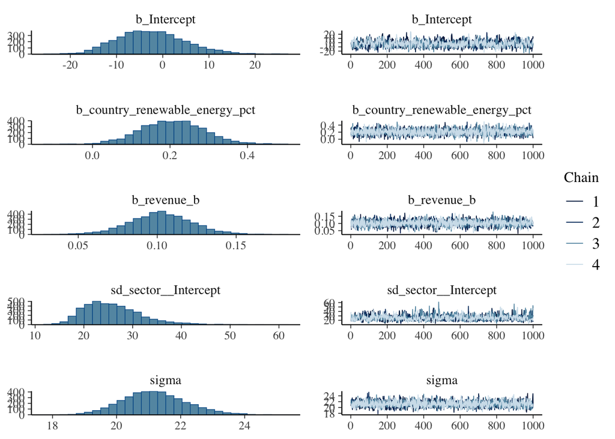

```r
plot(m1)
```

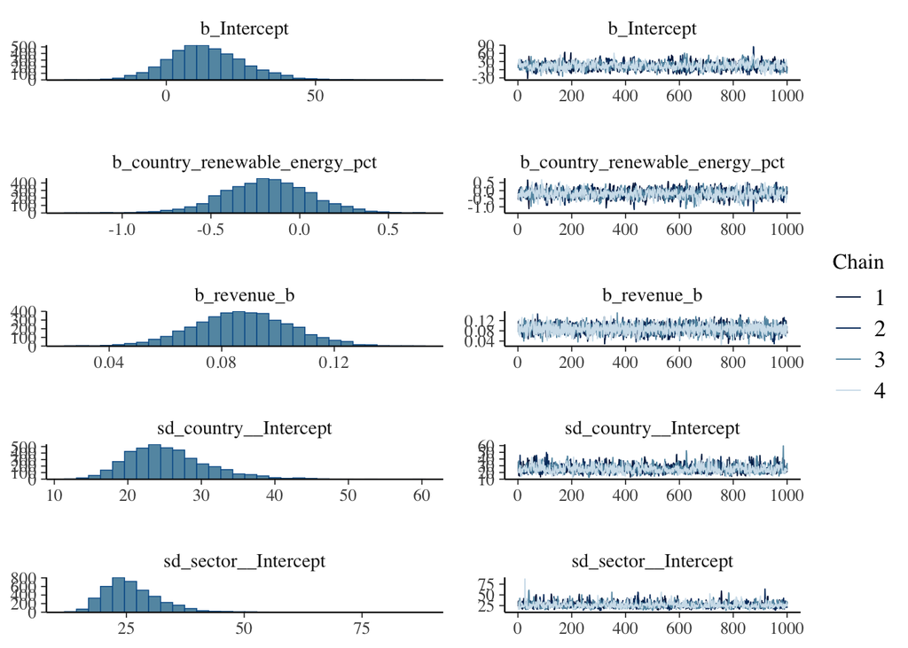

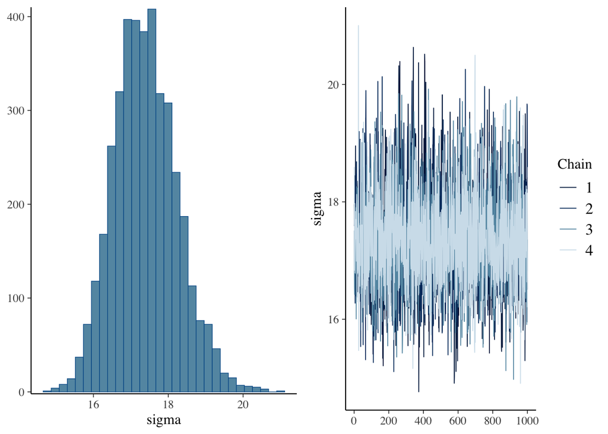

```r
plot(m2)
```

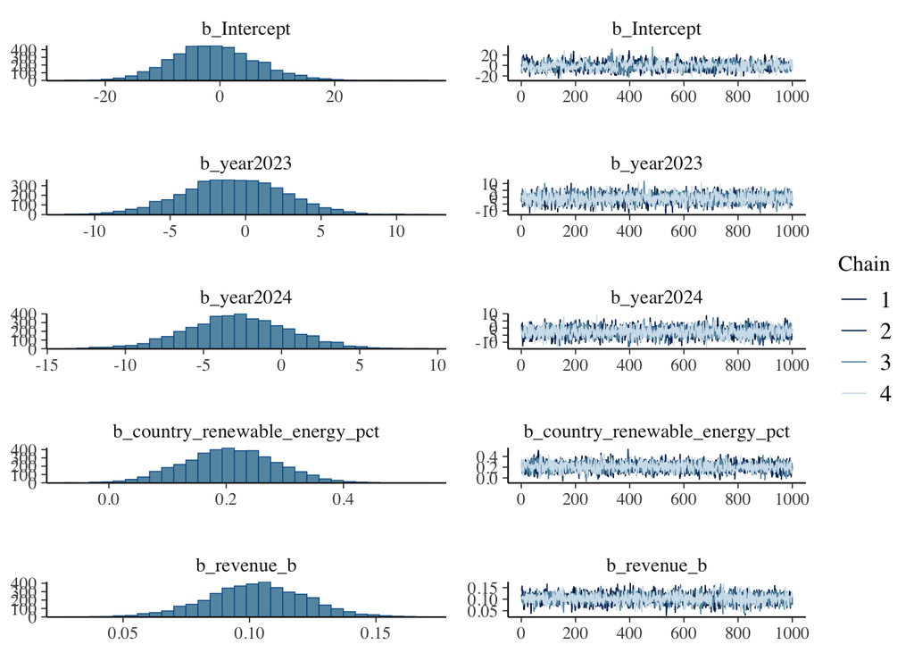

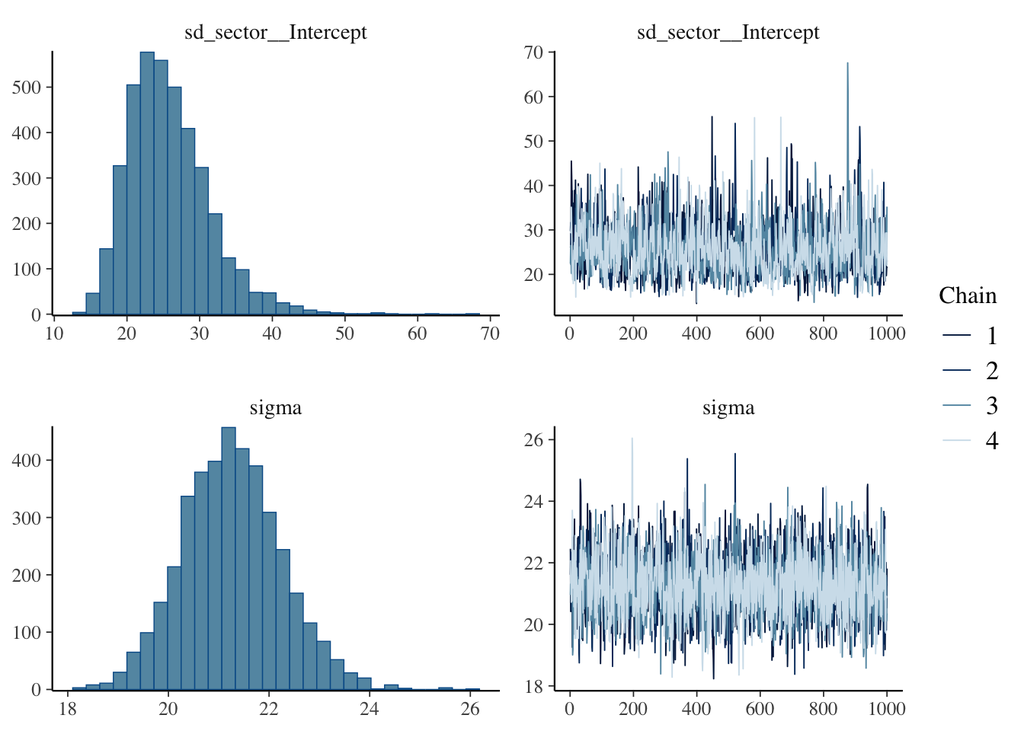

```r
plot(m3)
```

m1: M1 model converged well, as can be seen from 1.00 Rhat for all the variables. The same can be said after looking at trace plots for each variable, all four chains seem to mix well. The Bulk ESS for the intercepts was below 1000 (warning), which is common in multilevel models with few groups, due to posterior correlation between the global intercept and the group-level deviations. All Tail ESS were above 1000, so the tails (5th/95th percentiles) are estimated reliably.

m1: m1 is starting point model, so it used default (brms) priors, which would be examined later The model had varying intercept by sector (assuming that there is a group-level variance by sector), with revenue and a country’s usage of renewable energy as independent variables (which are assumed to be population-level effects and not to vary by group (sector)).

m2: m2 extends m1 by adding a varying intercept for country alongside sector. The model assumes that there is a group lever variance both between sectors and countries.Revenue and a country’s usage of renewable energy remain independent variables and are assumed to be population-level effects that do not vary by sector or country.

m3: m3 extends m1 by adding year as an additional independent variable. The model still has a varying intercept by sector, assuming that there is group-level variance between sectors. Revenue, country renewable energy percentage, and year are treated as population-level effects and are assumed not to vary by sector.

## 3. Model checking (3pt)

1. Perform a prior sensitivity analysis for each model and modify the model if appropriate. Justify your decision (whether you kept the model as-is or modified it). *(Max 150 words per model.)*

```r
powerscale_sensitivity(m1)
```

```
Sensitivity based on cjs_dist
Prior selection: all priors
Likelihood selection: all data

                                   variable prior likelihood
                                b_Intercept 0.142      0.021
             b_country_renewable_energy_pct 0.008      0.103
                                b_revenue_b 0.009      0.112
                       sd_sector__Intercept 0.112      0.041
                                      sigma 0.020      0.174
                                  Intercept 0.155      0.016
 r_sector[Construction.Materials,Intercept] 0.085      0.112
       r_sector[Consumer.Staples,Intercept] 0.121      0.026
                 r_sector[Energy,Intercept] 0.114      0.038
             r_sector[Financials,Intercept] 0.120      0.033
             r_sector[Healthcare,Intercept] 0.132      0.035
            r_sector[Industrials,Intercept] 0.118      0.036
              r_sector[Materials,Intercept] 0.123      0.035
            r_sector[Real.Estate,Intercept] 0.099      0.044
             r_sector[Technology,Intercept] 0.113      0.047
         r_sector[Transportation,Intercept] 0.123      0.027
              r_sector[Utilities,Intercept] 0.116      0.029
                                diagnosis
 potential strong prior / weak likelihood
                                        -
                                        -
 potential strong prior / weak likelihood
                                        -
 potential strong prior / weak likelihood
            potential prior-data conflict
 potential strong prior / weak likelihood
 potential strong prior / weak likelihood
 potential strong prior / weak likelihood
 potential strong prior / weak likelihood
 potential strong prior / weak likelihood
 potential strong prior / weak likelihood
 potential strong prior / weak likelihood
 potential strong prior / weak likelihood
 potential strong prior / weak likelihood
 potential strong prior / weak likelihood
```

```r
powerscale_sensitivity(m2)
```

```
Sensitivity based on cjs_dist
Prior selection: all priors
Likelihood selection: all data

                                   variable prior likelihood
                                b_Intercept 0.153      0.025
             b_country_renewable_energy_pct 0.057      0.051
                                b_revenue_b 0.009      0.089
                      sd_country__Intercept 0.109      0.180
                       sd_sector__Intercept 0.130      0.056
                                      sigma 0.017      0.346
                                  Intercept 0.214      0.047
             r_country[Australia,Intercept] 0.043      0.044
                r_country[Brazil,Intercept] 0.020      0.062
                r_country[Canada,Intercept] 0.021      0.096
                 r_country[China,Intercept] 0.027      0.037
               r_country[Denmark,Intercept] 0.021      0.063
                r_country[France,Intercept] 0.081      0.033
               r_country[Germany,Intercept] 0.075      0.019
               r_country[Ireland,Intercept] 0.067      0.077
                 r_country[Italy,Intercept] 0.066      0.054
            r_country[Luxembourg,Intercept] 0.012      0.291
                r_country[Mexico,Intercept] 0.044      0.099
           r_country[Netherlands,Intercept] 0.041      0.082
                r_country[Norway,Intercept] 0.024      0.023
           r_country[South.Korea,Intercept] 0.058      0.021
                 r_country[Spain,Intercept] 0.048      0.092
           r_country[Switzerland,Intercept] 0.034      0.075
                r_country[Taiwan,Intercept] 0.056      0.031
        r_country[United.Kingdom,Intercept] 0.071      0.058
         r_country[United.States,Intercept] 0.107      0.022
 r_sector[Construction.Materials,Intercept] 0.076      0.109
       r_sector[Consumer.Staples,Intercept] 0.107      0.027
                 r_sector[Energy,Intercept] 0.095      0.040
             r_sector[Financials,Intercept] 0.102      0.038
                                diagnosis
 potential strong prior / weak likelihood
            potential prior-data conflict
                                        -
            potential prior-data conflict
```

[output cut: 12 more lines]

```
                                        -
                                        -
                                        -
                                        -
 potential strong prior / weak likelihood
                                        -
                                        -
 potential strong prior / weak likelihood
            potential prior-data conflict
 potential strong prior / weak likelihood
            potential prior-data conflict
 potential strong prior / weak likelihood
 potential strong prior / weak likelihood
 potential strong prior / weak likelihood
 [ reached 'max' / getOption("max.print") -- omitted 7 rows ]
```

```r
powerscale_sensitivity(m3)
```

```
Sensitivity based on cjs_dist
Prior selection: all priors
Likelihood selection: all data

                                   variable prior likelihood
                                b_Intercept 0.130      0.025
                                 b_year2023 0.006      0.094
                                 b_year2024 0.006      0.099
             b_country_renewable_energy_pct 0.008      0.107
                                b_revenue_b 0.011      0.106
                       sd_sector__Intercept 0.108      0.042
                                      sigma 0.019      0.184
                                  Intercept 0.147      0.014
 r_sector[Construction.Materials,Intercept] 0.083      0.113
       r_sector[Consumer.Staples,Intercept] 0.116      0.015
                 r_sector[Energy,Intercept] 0.113      0.025
             r_sector[Financials,Intercept] 0.127      0.040
             r_sector[Healthcare,Intercept] 0.116      0.029
            r_sector[Industrials,Intercept] 0.114      0.027
              r_sector[Materials,Intercept] 0.116      0.024
            r_sector[Real.Estate,Intercept] 0.106      0.031
             r_sector[Technology,Intercept] 0.119      0.032
         r_sector[Transportation,Intercept] 0.112      0.030
              r_sector[Utilities,Intercept] 0.110      0.029
                                diagnosis
 potential strong prior / weak likelihood
                                        -
                                        -
                                        -
                                        -
 potential strong prior / weak likelihood
                                        -
 potential strong prior / weak likelihood
            potential prior-data conflict
 potential strong prior / weak likelihood
 potential strong prior / weak likelihood
 potential strong prior / weak likelihood
 potential strong prior / weak likelihood
 potential strong prior / weak likelihood
 potential strong prior / weak likelihood
 potential strong prior / weak likelihood
 potential strong prior / weak likelihood
 potential strong prior / weak likelihood
 potential strong prior / weak likelihood
```

m2 & m3:

The same diagnostic pattern appears for m2 and m3 (several “strong prior / weak likelihood” flags and some prior-data conflict, e.g. on sigma and the country sd). We apply the same modification for consistency, lognormal likelihood with the same weakly-informative priors, so that the three models differ only in their multilevel structure and remain directly comparable, rather than differing in likelihood or priors. This yields m2_ln and m3_ln.

```r
priors_ln <- c(
  prior(normal(0, 0.5), class = "b", coef = "country_renewable_energy_pct"),
  prior(normal(0, 0.1), class = "b", coef = "revenue_b"),
  prior(normal(1.5, 1), class = "Intercept"),
  prior(exponential(1), class = "sd"),
  prior(exponential(1), class = "sigma")
)

m1_ln <- brm(co2_mt ~ country_renewable_energy_pct + revenue_b + (1 | sector),
             data = ghg_train, family = lognormal(),
             prior = priors_ln, seed = 123)

m2_ln <- brm(co2_mt ~ country_renewable_energy_pct + revenue_b + (1 | sector) +
  (1 | country),
  data = ghg_train,
  family = lognormal(),
  prior = priors_ln,
  seed = 123,
  control = list(adapt_delta = 0.99)
)

m3_ln <- brm(co2_mt ~ year + country_renewable_energy_pct + revenue_b +
  (1 | sector),
  data = ghg_train,
  family = lognormal(),
  prior = priors_ln,
  seed = 123
)
```

```r
summary(m1_ln)
```

```
 Family: lognormal
  Links: mu = identity
Formula: co2_mt ~ country_renewable_energy_pct + revenue_b + (1 | sector)
   Data: ghg_train (Number of observations: 240)
  Draws: 4 chains, each with iter = 2000; warmup = 1000; thin = 1;
         total post-warmup draws = 4000

Multilevel Hyperparameters:
~sector (Number of levels: 11)
              Estimate Est.Error l-95% CI u-95% CI Rhat Bulk_ESS Tail_ESS
sd(Intercept)     2.31      0.49     1.56     3.46 1.00      686     1000

Regression Coefficients:
                             Estimate Est.Error l-95% CI u-95% CI Rhat Bulk_ESS Tail_ESS
Intercept                        0.64      0.61    -0.56     1.88 1.01      884     1180
country_renewable_energy_pct     0.00      0.00    -0.01     0.01 1.00     2424     2184
revenue_b                        0.01      0.00     0.00     0.01 1.00     4986     3327

Further Distributional Parameters:
      Estimate Est.Error l-95% CI u-95% CI Rhat Bulk_ESS Tail_ESS
sigma     1.14      0.05     1.04     1.25 1.00     2260     1892

Draws were sampled using sampling(NUTS). For each parameter, Bulk_ESS
and Tail_ESS are effective sample size measures, and Rhat is the potential
scale reduction factor on split chains (at convergence, Rhat = 1).
```

```r
summary(m2_ln)
```

```
 Family: lognormal
  Links: mu = identity
Formula: co2_mt ~ country_renewable_energy_pct + revenue_b + (1 | sector) + (1 | country)
   Data: ghg_train (Number of observations: 240)
  Draws: 4 chains, each with iter = 2000; warmup = 1000; thin = 1;
         total post-warmup draws = 4000

Multilevel Hyperparameters:
~country (Number of levels: 19)
              Estimate Est.Error l-95% CI u-95% CI Rhat Bulk_ESS Tail_ESS
sd(Intercept)     1.43      0.31     0.93     2.12 1.00     1314     2170

~sector (Number of levels: 11)
              Estimate Est.Error l-95% CI u-95% CI Rhat Bulk_ESS Tail_ESS
sd(Intercept)     2.40      0.51     1.66     3.61 1.00     1103     1607

Regression Coefficients:
                             Estimate Est.Error l-95% CI u-95% CI Rhat Bulk_ESS Tail_ESS
Intercept                        1.67      0.84     0.06     3.36 1.00     1445     1742
country_renewable_energy_pct    -0.01      0.01    -0.04     0.01 1.00     1524     1864
revenue_b                        0.00      0.00     0.00     0.01 1.00     5202     3331

Further Distributional Parameters:
      Estimate Est.Error l-95% CI u-95% CI Rhat Bulk_ESS Tail_ESS
sigma     0.95      0.05     0.87     1.05 1.00     4229     2514

Draws were sampled using sampling(NUTS). For each parameter, Bulk_ESS
and Tail_ESS are effective sample size measures, and Rhat is the potential
scale reduction factor on split chains (at convergence, Rhat = 1).
```

```r
summary(m3_ln)
```

```
 Family: lognormal
  Links: mu = identity
Formula: co2_mt ~ year + country_renewable_energy_pct + revenue_b + (1 | sector)
   Data: ghg_train (Number of observations: 240)
  Draws: 4 chains, each with iter = 2000; warmup = 1000; thin = 1;
         total post-warmup draws = 4000

Multilevel Hyperparameters:
~sector (Number of levels: 11)
              Estimate Est.Error l-95% CI u-95% CI Rhat Bulk_ESS Tail_ESS
sd(Intercept)     2.30      0.48     1.56     3.41 1.01      757     1356

Regression Coefficients:
                             Estimate Est.Error l-95% CI u-95% CI Rhat Bulk_ESS Tail_ESS
Intercept                        0.74      0.65    -0.54     2.08 1.01      861     1113
year2023                        -0.11      0.18    -0.47     0.24 1.00     2731     2667
year2024                        -0.20      0.18    -0.56     0.16 1.00     2616     2528
country_renewable_energy_pct     0.00      0.00    -0.01     0.01 1.00     3966     2435
revenue_b                        0.01      0.00     0.00     0.01 1.00     4218     3086

Further Distributional Parameters:
      Estimate Est.Error l-95% CI u-95% CI Rhat Bulk_ESS Tail_ESS
sigma     1.14      0.05     1.04     1.25 1.00     3022     2629

Draws were sampled using sampling(NUTS). For each parameter, Bulk_ESS
and Tail_ESS are effective sample size measures, and Rhat is the potential
scale reduction factor on split chains (at convergence, Rhat = 1).
```

```r
powerscale_sensitivity(m1_ln)
```

```
Sensitivity based on cjs_dist
Prior selection: all priors
Likelihood selection: all data

                                   variable prior likelihood
                                b_Intercept 0.045      0.024
             b_country_renewable_energy_pct 0.005      0.122
                                b_revenue_b 0.003      0.093
                       sd_sector__Intercept 0.121      0.023
                                      sigma 0.012      0.168
                                  Intercept 0.049      0.023
 r_sector[Construction.Materials,Intercept] 0.042      0.046
       r_sector[Consumer.Staples,Intercept] 0.047      0.027
                 r_sector[Energy,Intercept] 0.046      0.034
             r_sector[Financials,Intercept] 0.042      0.024
             r_sector[Healthcare,Intercept] 0.044      0.027
            r_sector[Industrials,Intercept] 0.044      0.031
              r_sector[Materials,Intercept] 0.047      0.036
            r_sector[Real.Estate,Intercept] 0.035      0.025
             r_sector[Technology,Intercept] 0.041      0.024
         r_sector[Transportation,Intercept] 0.044      0.035
              r_sector[Utilities,Intercept] 0.047      0.034
                                diagnosis
                                        -
                                        -
                                        -
 potential strong prior / weak likelihood
                                        -
                                        -
                                        -
                                        -
                                        -
                                        -
                                        -
                                        -
                                        -
                                        -
                                        -
                                        -
                                        -
```

```r
powerscale_sensitivity(m2_ln)
```

```
Sensitivity based on cjs_dist
Prior selection: all priors
Likelihood selection: all data

                                   variable prior likelihood
                                b_Intercept 0.042      0.030
             b_country_renewable_energy_pct 0.012      0.029
                                b_revenue_b 0.003      0.124
                      sd_country__Intercept 0.074      0.171
                       sd_sector__Intercept 0.142      0.036
                                      sigma 0.005      0.367
                                  Intercept 0.054      0.040
             r_country[Australia,Intercept] 0.012      0.088
                r_country[Brazil,Intercept] 0.011      0.022
                r_country[Canada,Intercept] 0.021      0.317
                 r_country[China,Intercept] 0.011      0.062
               r_country[Denmark,Intercept] 0.015      0.018
                r_country[France,Intercept] 0.016      0.040
               r_country[Germany,Intercept] 0.016      0.036
               r_country[Ireland,Intercept] 0.014      0.092
                 r_country[Italy,Intercept] 0.013      0.076
            r_country[Luxembourg,Intercept] 0.009      0.063
                r_country[Mexico,Intercept] 0.010      0.065
           r_country[Netherlands,Intercept] 0.006      0.052
                r_country[Norway,Intercept] 0.014      0.030
           r_country[South.Korea,Intercept] 0.016      0.128
                 r_country[Spain,Intercept] 0.017      0.100
           r_country[Switzerland,Intercept] 0.014      0.018
                r_country[Taiwan,Intercept] 0.010      0.095
        r_country[United.Kingdom,Intercept] 0.019      0.028
         r_country[United.States,Intercept] 0.018      0.020
 r_sector[Construction.Materials,Intercept] 0.034      0.063
       r_sector[Consumer.Staples,Intercept] 0.041      0.035
                 r_sector[Energy,Intercept] 0.038      0.043
             r_sector[Financials,Intercept] 0.041      0.028
                                diagnosis
                                        -
                                        -
                                        -
            potential prior-data conflict
```

[output cut: 12 more lines]

```
                                        -
                                        -
                                        -
                                        -
                                        -
                                        -
                                        -
                                        -
                                        -
                                        -
                                        -
                                        -
                                        -
                                        -
 [ reached 'max' / getOption("max.print") -- omitted 7 rows ]
```

```r
powerscale_sensitivity(m3_ln)
```

```
Sensitivity based on cjs_dist
Prior selection: all priors
Likelihood selection: all data

                                   variable prior likelihood
                                b_Intercept 0.045      0.011
                                 b_year2023 0.004      0.085
                                 b_year2024 0.002      0.089
             b_country_renewable_energy_pct 0.005      0.088
                                b_revenue_b 0.003      0.093
                       sd_sector__Intercept 0.118      0.027
                                      sigma 0.011      0.187
                                  Intercept 0.051      0.014
 r_sector[Construction.Materials,Intercept] 0.043      0.025
       r_sector[Consumer.Staples,Intercept] 0.045      0.012
                 r_sector[Energy,Intercept] 0.045      0.013
             r_sector[Financials,Intercept] 0.041      0.014
             r_sector[Healthcare,Intercept] 0.044      0.011
            r_sector[Industrials,Intercept] 0.045      0.016
              r_sector[Materials,Intercept] 0.047      0.016
            r_sector[Real.Estate,Intercept] 0.044      0.020
             r_sector[Technology,Intercept] 0.042      0.014
         r_sector[Transportation,Intercept] 0.047      0.011
              r_sector[Utilities,Intercept] 0.047      0.018
                                diagnosis
                                        -
                                        -
                                        -
                                        -
                                        -
 potential strong prior / weak likelihood
                                        -
 potential strong prior / weak likelihood
                                        -
                                        -
                                        -
                                        -
                                        -
                                        -
                                        -
                                        -
                                        -
                                        -
                                        -
```

m1_ln:

After switching to the lognormal likelihood, the power-scaling diagnostic improves markedly: only one parameter (the sector intercept sd) is flagged as “strong prior / weak likelihood”, against many flags in the Gaussian m1. This residual flag is expected, since with 11 sectors the data weakly inform the group-level sd. We judge the model robust enough and keep m1_ln as is.

2. Conduct posterior predictive checks for each model to assess how well they fit the data. Explain what you conclude. *(Max 150 words per model.)*

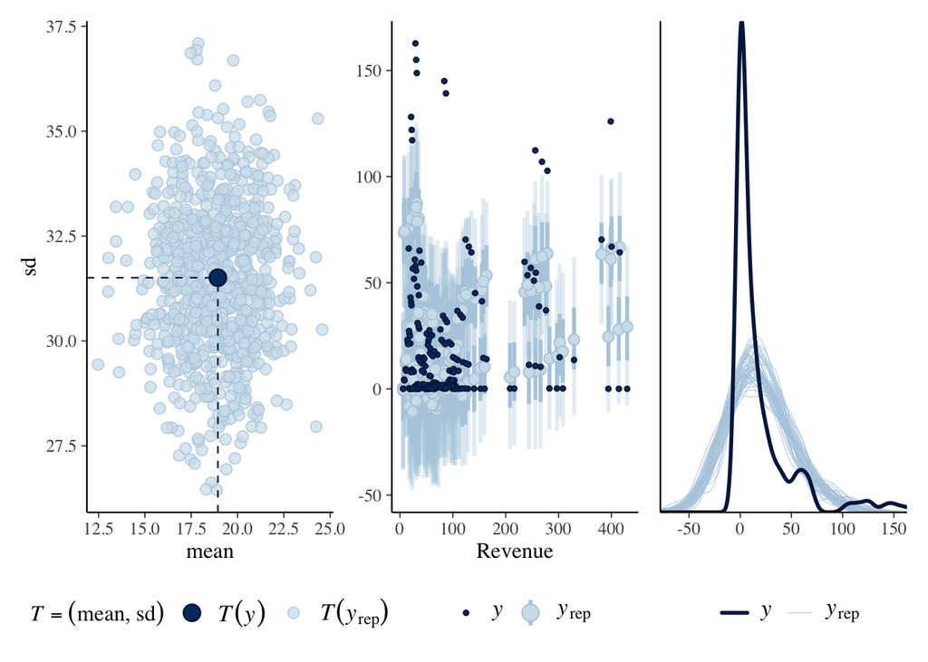

```r
# posterior predictive check for m1
yrep_h0 <- posterior_predict(m1, ndraws = 800)

p1 <- bayesplot::ppc_stat_2d(ghg_train$co2_mt, yrep_h0) +
  theme(legend.position = "bottom")
p2 <- bayesplot::ppc_intervals(ghg_train$co2_mt, yrep_h0,
                               x = c(ghg_train$revenue_b)) +
  theme(legend.position = "bottom") + xlab("Revenue")
p3 <- bayesplot::ppc_dens_overlay(ghg_train$co2_mt, yrep_h0[1:50, ]) +
  theme(legend.position = "bottom")
p1 + p2 + p3
```

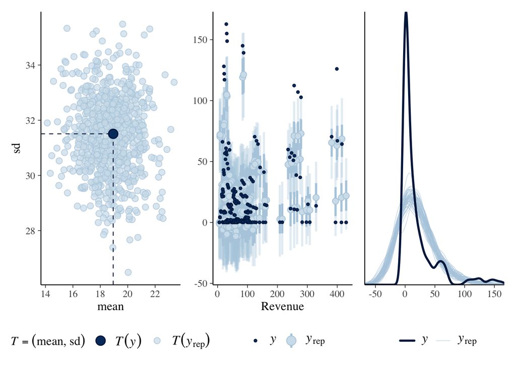

```r
# posterior predictive check for m2
yrep_m2 <- posterior_predict(m2, ndraws = 800)

p1_m2 <- bayesplot::ppc_stat_2d(ghg_train$co2_mt, yrep_m2) +
  theme(legend.position = "bottom")

p2_m2 <- bayesplot::ppc_intervals(ghg_train$co2_mt,yrep_m2,x = ghg_train$revenue_b) +
  theme(legend.position = "bottom") +
  xlab("Revenue")

p3_m2 <- bayesplot::ppc_dens_overlay(ghg_train$co2_mt,yrep_m2[1:50, ]) +
  theme(legend.position = "bottom")

p1_m2 + p2_m2 + p3_m2
```

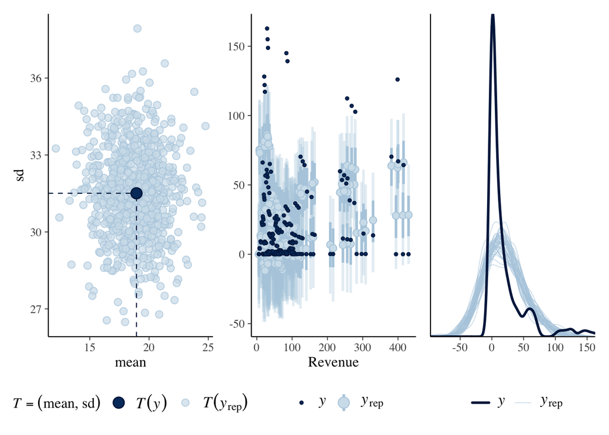

```r
# posterior predictive check for m3
yrep_m3 <- posterior_predict(m3, ndraws = 800)

p1_m3 <- bayesplot::ppc_stat_2d(ghg_train$co2_mt, yrep_m3) +
  theme(legend.position = "bottom")

p2_m3 <- bayesplot::ppc_intervals(ghg_train$co2_mt,yrep_m3,x = ghg_train$revenue_b) +
  theme(legend.position = "bottom") +
  xlab("Revenue")

p3_m3 <- bayesplot::ppc_dens_overlay(ghg_train$co2_mt,yrep_m3[1:50, ]) +
  theme(legend.position = "bottom")

p1_m3 + p2_m3 + p3_m3
```

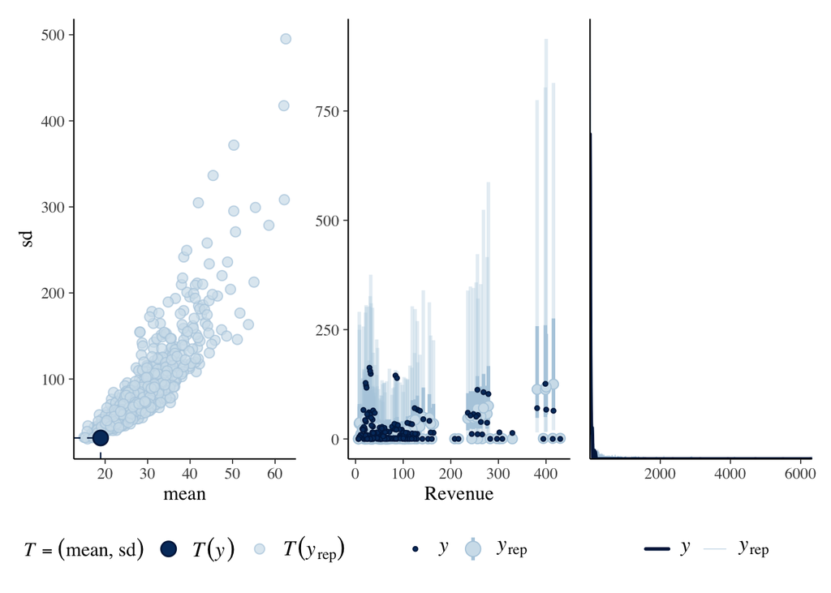

```r
# posterior predictive check for m1_ln
yrep_h0 <- posterior_predict(m1_ln, ndraws = 800)

p1_m1_ln <- bayesplot::ppc_stat_2d(ghg_train$co2_mt, yrep_h0) +
  theme(legend.position = "bottom")
p2_m1_ln <- bayesplot::ppc_intervals(ghg_train$co2_mt, yrep_h0,
                               x = c(ghg_train$revenue_b)) +
  theme(legend.position = "bottom") + xlab("Revenue")
p3_m1_ln <- bayesplot::ppc_dens_overlay(ghg_train$co2_mt, yrep_h0[1:50, ]) +
  theme(legend.position = "bottom")
p1_m1_ln + p2_m1_ln + p3_m1_ln
```

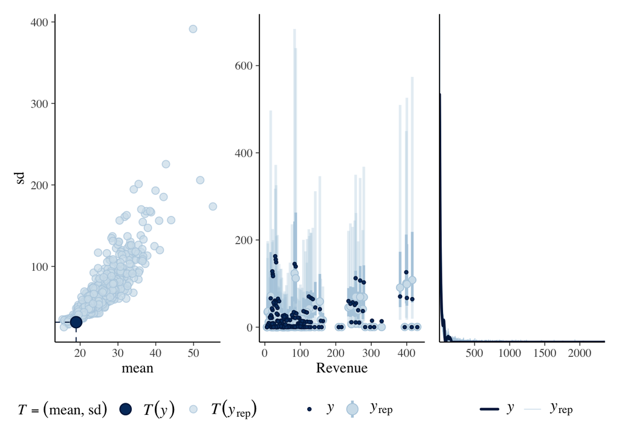

```r
# posterior predictive check for m2_ln
yrep_h0 <- posterior_predict(m2_ln, ndraws = 800)

p1_m1_ln <- bayesplot::ppc_stat_2d(ghg_train$co2_mt, yrep_h0) +
  theme(legend.position = "bottom")
p2_m1_ln <- bayesplot::ppc_intervals(ghg_train$co2_mt, yrep_h0,
                               x = c(ghg_train$revenue_b)) +
  theme(legend.position = "bottom") + xlab("Revenue")
p3_m1_ln <- bayesplot::ppc_dens_overlay(ghg_train$co2_mt, yrep_h0[1:50, ]) +
  theme(legend.position = "bottom")
p1_m1_ln + p2_m1_ln + p3_m1_ln
```

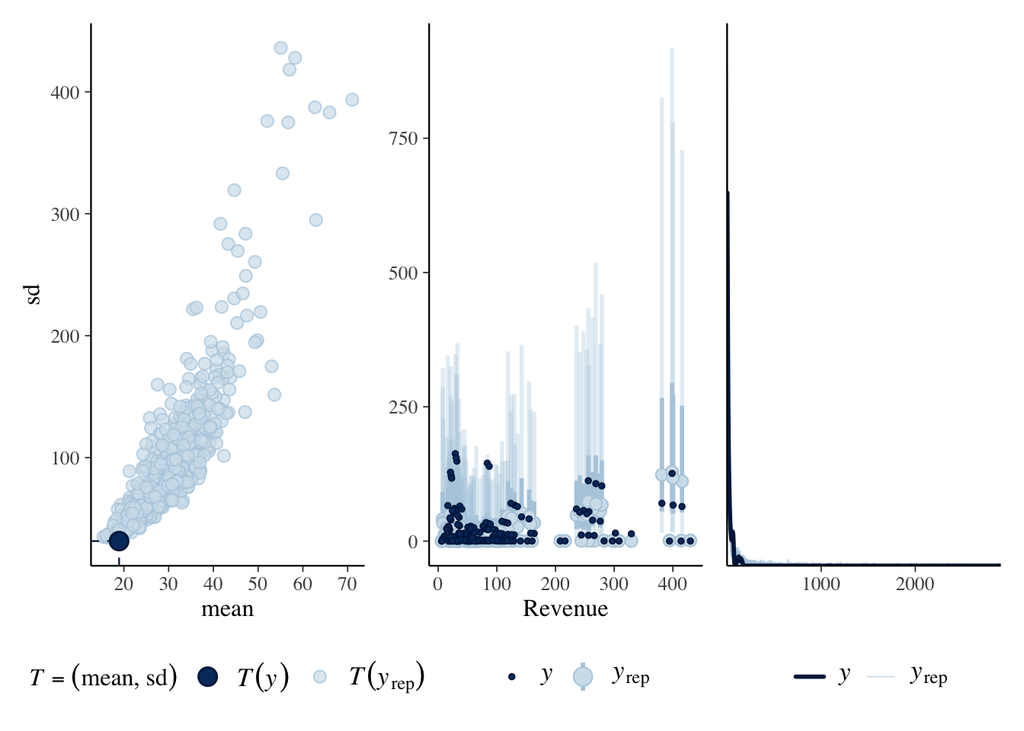

```r
# posterior predictive check for m3_ln
yrep_h0 <- posterior_predict(m3_ln, ndraws = 800)

p1_m1_ln <- bayesplot::ppc_stat_2d(ghg_train$co2_mt, yrep_h0) +
  theme(legend.position = "bottom")
p2_m1_ln <- bayesplot::ppc_intervals(ghg_train$co2_mt, yrep_h0,
                               x = c(ghg_train$revenue_b)) +
  theme(legend.position = "bottom") + xlab("Revenue")
p3_m1_ln <- bayesplot::ppc_dens_overlay(ghg_train$co2_mt, yrep_h0[1:50, ]) +
  theme(legend.position = "bottom")
p1_m1_ln + p2_m1_ln + p3_m1_ln
```

m3_ln (sector + year). Essentially indistinguishable from m1_ln in shape and coverage, consistent with the very small year coefficients: adding year does not change the predictive distribution. The mean/sd statistic and the density overlay are reproduced as well as in the other two models.

## 4. Model Comparison (1.5pt)

Fabio a. Use k-fold cross-validation to compare the models using the log-score. State the value of k you used and briefly justify it.

```r
# K = 10: with 300 rows it's the standard bias/variance compromise;

# Safety: m3_ln uses year as a factor — make sure both sets agree.
ghg_train$year <- factor(ghg_train$year)
ghg_test$year  <- factor(ghg_test$year, levels = levels(ghg_train$year))

set.seed(123)
K <- 10
folds <- loo::kfold_split_random(K = K, N = nrow(ghg_train))

kf_m1_ln <- kfold(m1_ln, folds = folds)
kf_m2_ln <- kfold(m2_ln, folds = folds)
kf_m3_ln <- kfold(m3_ln, folds = folds)

loo_compare(kf_m1_ln, kf_m2_ln, kf_m3_ln)
```

```
      elpd_diff se_diff
m2_ln   0.0       0.0
m1_ln -36.8      14.0
m3_ln -38.8      13.9
```

We use k = 10. With 240 training observations, 10-fold cross-validation is the standard bias–variance compromise: each fold leaves out enough data (~24 observations) for a reliable out-of-sample estimate, while refitting only 10 times per model keeps the computation feasible.

2. Determine the best model based on predictive accuracy and justify your decision. *(Max 100 words.)*

Using 10-fold cross-validation, m2_ln has the highest ELPD. Following the rule Δelpd > 4 and Δ > 2 SE for a reliable difference: m2_ln beats m1_ln by 36.8 (SE 14.0; 2 SE = 28.0) and m3_ln by 38.8 (SE 13.9; 2 SE = 27.8). Both gaps clear the 4-point and the 2 SE thresholds, so m2_ln is reliably better. Substantively, m2_ln is the only model with a country-level varying intercept, capturing between-country variation in emissions (energy mix, regulation). Adding year (m3_ln) does not help. We select m2_ln.

3. Report the **log-score on the held-out test set** for the best model. Make sure the test set is scaled/encoded with statistics from the training set (no data leakage). Briefly compare with the cross-validated estimate. *(Max 100 words.)*

```r
# Pointwise log predictive density on the test set
ll_test <- log_lik(
  m2_ln,
  newdata = ghg_test,
  allow_new_levels = TRUE
)  # draws x n_test matrix

# Test log-score = sum over test points of log( mean over draws of likelihood )
elpd_test_pointwise <- apply(ll_test, 2, function(col) {
  matrixStats::logSumExp(col) - log(length(col))
})
elpd_test <- sum(elpd_test_pointwise)
n_test    <- ncol(ll_test)

# Report total and per-observation, to compare fairly with k-fold
elpd_test                       # total test log-score
```

```
[1] -157.7701
```

```r
elpd_test / n_test              # per-observation test log-score
```

```
[1] -2.629501
```

```r
# k-fold estimate for the same model, on a per-observation basis
kf_m2_ln$estimates["elpd_kfold", "Estimate"] / nrow(ghg_train)
```

```
[1] -2.506867
```

We fit m2_ln on the training set only and evaluated its log predictive density on the held-out test set (n = 60). No scaling statistics are carried over because the predictors are used in raw units, so there is no leakage; the only training-derived encoding is the set of sector/country factor levels, handled with allow_new_levels = TRUE. The total test log-score was −157.77, i.e. −2.63 per observation. This is very close to the cross-validated estimate of −2.51 per observation (only 0.12 lower), indicating that m2_ln generalizes well, with the small gap consistent with a few large emitters being influential on a small test set.

## 5. Interpretation of Important Parameters (1.5pt)

Fabio Take the best model from question 4 and interpret its most important parameters — focus on the parameters that matter for the research question or the intended use of the dataset (mentioned in question 1). *(Max 250 words.)*

```r
summary(m2_ln)
```

```
 Family: lognormal
  Links: mu = identity
Formula: co2_mt ~ country_renewable_energy_pct + revenue_b + (1 | sector) + (1 | country)
   Data: ghg_train (Number of observations: 240)
  Draws: 4 chains, each with iter = 2000; warmup = 1000; thin = 1;
         total post-warmup draws = 4000

Multilevel Hyperparameters:
~country (Number of levels: 19)
              Estimate Est.Error l-95% CI u-95% CI Rhat Bulk_ESS Tail_ESS
sd(Intercept)     1.43      0.31     0.93     2.12 1.00     1314     2170

~sector (Number of levels: 11)
              Estimate Est.Error l-95% CI u-95% CI Rhat Bulk_ESS Tail_ESS
sd(Intercept)     2.40      0.51     1.66     3.61 1.00     1103     1607

Regression Coefficients:
                             Estimate Est.Error l-95% CI u-95% CI Rhat Bulk_ESS Tail_ESS
Intercept                        1.67      0.84     0.06     3.36 1.00     1445     1742
country_renewable_energy_pct    -0.01      0.01    -0.04     0.01 1.00     1524     1864
revenue_b                        0.00      0.00     0.00     0.01 1.00     5202     3331

Further Distributional Parameters:
      Estimate Est.Error l-95% CI u-95% CI Rhat Bulk_ESS Tail_ESS
sigma     0.95      0.05     0.87     1.05 1.00     4229     2514

Draws were sampled using sampling(NUTS). For each parameter, Bulk_ESS
and Tail_ESS are effective sample size measures, and Rhat is the potential
scale reduction factor on split chains (at convergence, Rhat = 1).
```

```r
fixef(m2_ln, probs = c(0.025, 0.975))["revenue_b", ]
```

```
    Estimate    Est.Error         Q2.5        Q97.5
0.0047153314 0.0009275895 0.0028770935 0.0065421032
```

The best model (m2_ln) predicts company-level Scope 1 emissions from revenue and national renewable-energy share, with varying intercepts for sector and country. Because the likelihood is lognormal, coefficients act multiplicatively on emissions through exp(·). Renewable-energy share has a coefficient of −0.01 (95% CI [−0.04, 0.01]): the interval spans zero, so once sector and country are accounted for, national renewable use shows no clear association with a company’s emissions. Revenue has a small but credibly positive effect (0.0047, 95% CI [0.0029, 0.0065], excluding zero): on the log scale each additional billion USD multiplies expected emissions by about exp(0.0047) ≈ 1.005, under 0.5%. Within a given sector and country, firm revenue therefore adds little. The substantive story lies in the grouping structure. The sector standard deviation is 2.40 (CI [1.66, 3.61]) and the country standard deviation is 1.43 (CI [0.93, 2.12]). Exponentiating, typical emissions vary by roughly a factor of 11 across sectors and a factor of 4 across countries, sector being clearly the dominant source of variation. Decomposing the variance on the log scale (2.40² + 1.43² + 0.95²) attributes about 66% to sector, 23% to country, and only 10% to residual within-group variation. The key message: a company’s emissions are driven overwhelmingly by what it does (sector) and where it operates (country), far more than by its revenue or its country’s renewable mix. This justifies the multilevel structure and explains why adding the country level (m2_ln) outperformed the alternatives.

## 6. Report a loss function with cross-validation (Optional bonus, 0.5 to 1pt, depending on whether you use RMSE or another function).

Fabio a. Report RMSE or another loss (or utility) function, computed with k-fold cross-validation. Do you reach the same conclusion as in question 4 (model comparison)? *(Max 100 words.)*

```r
set.seed(123)
K <- 10
folds <- loo::kfold_split_random(K = K, N = nrow(ghg_train))

kf_m1_ln_f <- kfold(m1_ln, folds = folds, save_fits = TRUE)
kf_m2_ln_f <- kfold(m2_ln, folds = folds, save_fits = TRUE)
kf_m3_ln_f <- kfold(m3_ln, folds = folds, save_fits = TRUE)

# Out-of-sample RMSE on the original (Mt) scale
kfold_rmse <- function(kf, data, yname = "co2_mt") {
  obs  <- data[[yname]]
  yhat <- rep(NA_real_, nrow(data))
  for (k in seq_len(nrow(kf$fits))) {
    fit_k   <- kf$fits[[k, "fit"]]
    omitted <- kf$fits[[k, "omitted"]]
    pred    <- posterior_epred(fit_k, newdata = data[omitted, , drop = FALSE],
                               allow_new_levels = TRUE)
    yhat[omitted] <- colMeans(pred)
  }
  sqrt(mean((obs - yhat)^2))
}

rmse_m1_ln <- kfold_rmse(kf_m1_ln_f, ghg_train)
rmse_m2_ln <- kfold_rmse(kf_m2_ln_f, ghg_train)
rmse_m3_ln <- kfold_rmse(kf_m3_ln_f, ghg_train)

c(m1_ln = rmse_m1_ln, m2_ln = rmse_m2_ln, m3_ln = rmse_m3_ln)
```

```
   m1_ln    m2_ln    m3_ln
31.78526 94.63052 32.30541
```

Using the same 10-fold partition as in Q4, we computed RMSE on the original (Mt) scale from the held-out posterior expected predictions: m1_ln ≈ 31.8, m3_ln ≈ 32.3, and m2_ln ≈ 94.6. This does not match Q4: under the log-score m2_ln was the best model, but under RMSE it is clearly the worst. The reason is structural — m2_ln’s country-level varying intercept is poorly identified for countries with only three observations (e.g. Mexico, Australia, Spain), producing a few extreme predictions that dominate squared-error loss. The log-score weights the entire predictive density and is far less affected by these few cases.

2. Report the same metric on the **held-out test set** for the best model from question 4. Again, scale/encode the test set with training-set statistics. *(Max 50 words.)*

```r
set.seed(123)
pred_test <- posterior_epred(m1_ln, newdata = ghg_test,
                             allow_new_levels = TRUE)
yhat_test <- colMeans(pred_test)
rmse_test <- sqrt(mean((ghg_test$co2_mt - yhat_test)^2))
rmse_test
```

```
[1] 37.99424
```

We use m1_ln (the RMSE-best model; m2_ln is unstable under squared error). Fit on training data only, predictors in raw units, sector levels from training. Held-out test RMSE was 38.0 Mt, close to the cross-validated ≈31.8 Mt — a modest gap, driven by a few large emitters in a small test set.

# Contributions of each member

- Sviatoslav Naumov - data set finding, data exploration and manipulation, fitting and examining the first (base) model
- Fuad Mahamed - fitting and explaining models m2 and m3 (Q2); prior sensitivity analysis and likelihood modification to lognormal (Q3a); posterior predictive checks for all models (Q3b)
- Fabio Pugno - model comparison via k-fold cross-validation with the log-score and held-out test-set evaluation (Q4); interpretation of the best model’s parameters (Q5); RMSE loss via cross-validation and on the test set (Q6a, Q6b)

# Statement of technology

Disclose any AI tools (e.g., ChatGPT, Claude, Copilot, Gemini) used while preparing this submission. Be specific — vague statements like “we used ChatGPT to help” are not acceptable.

For each tool used, report: - Sviatoslav - - **Tool and version** (Claude Opus 4.8). - **Which questions / parts of the submission** it was used for Q3a priors and likelihood modification. - **What kind of help** it provided. - Suggesting priors and likelihood (and explaining issues with default) - **How you verified the output** I integrated its suggestions, and ran the code, then compared the models, while consulting with workbooks to examine the suggested priors.

-Fuad - - **Tool and version:** Chatgpt, gpt 5.5 - **Which questions / parts:** Model checking and exploration for m2 and m3 - **What kind of help:** what kind of variable i could use for m2 and m3, general reasoning of the output. - **How you verified the output:** I ran all code myself, checked the all the post model info that you can gain. while at the same time looking at the workbooks. Working with my own reasoning and that of the ai, the conclusion is written.

- Fabio -
- **Tool and version:** Claude Opus 4.8
- **Which questions / parts:** Q4, Q5, Q6 (and dataset-selection support in Q1).
- **What kind of help:** debugging and improving my R/brms code for k-fold cross-validation, log-score and RMSE (including fixing a NaN error and switching from posterior_predict to posterior_epred for stable lognormal predictions); explaining the underlying concepts (the Δelpd > 4 and Δ > 2 SE rule, why log-score and RMSE can disagree, the multiplicative interpretation of lognormal coefficients); and drafting wording for the written answers.
- **How you verified the output:** I ran all the code and checked every result, diagnosed the m2_ln RMSE anomaly by inspecting the worst-predicted observations, and cross-checked the comparison rule against the lecture slides before finalizing the answers.

If no AI tools were used, state that explicitly.

You are responsible for everything in this submission, including content produced with AI assistance. Undisclosed use of AI tools will be treated as academic misconduct.

# References

- GHG Emissions and Finance — Global Companies 2022–2024. Kaggle. https://www.kaggle.com/datasets/hussnainmamoon1/ghg-emissions-and-finance-global-companies-2022-2024